# Banking Capstone - Data Wrangling and Stastical Analysis

Demetri Lee

December 1, 2018

## Working to predict the success of bank marketing

I’m working on predicting the success of telemarketing calls for a bank that’s selling long-term deposits. A Portuguese retail bank was addressed, with data collected from 2008 to 2013, thus including the effects of the recent financial crisis of 2008. With 21 variables available for analysis, I hope to derive knowledge for a model that would confirm how to better focus resources towards clients with a high chance of agreeing to registering for extra banking services.

### This is the data dictionary provided by the respective retail bank:

**Bank client data**

1. age: numeric
2. job: type of job (categorical: admin, blue-collar, entrepreneur, housemaid, management, retired, self-employed, services, student, technician, unemployed, unknown)
3. marital: marital status (categorical: divorced, married, single, unknown; note: ‘divorced’ means divorced or widowed)
4. education: (categorical: basic.4y, basic.6y, basic.9y, high.school, illiterate, professional.course, university.degree, unknown)
5. default: has credit in default? (categorical: no, yes, unknown)
6. housing: has housing loan? (categorical: no, yes, unknown)
7. loan: has personal loan? (categorical: no, yes, unknown)

**Related with the last contact of the current campaign**

8. contact: contact communication type (categorical: cellular, telephone)
9. month: last contact month of year (categorical: jan’, ‘feb’, ‘mar’, …, ‘nov’, ‘dec’)
10. day_of_week: last contact day of the week (categorical: mon, tue, wed, thu, fri)
11. duration: last contact duration, in seconds (numeric). Important note: this attribute highly affects the output target (e.g., if duration=0 then y=‘no’). Yet, the duration is not known before a call is performed. Also, after the end of the call y is obviously known. Thus, this input should only be included for benchmark purposes and should be discarded if the intention is to have a realistic predictive model.

**Other attributes**

12. campaign: number of contacts performed during this campaign and for this client (numeric, includes last contact)
13. pdays: number of days that passed by after the client was last contacted from a previous campaign (numeric; 999 means client was not previously contacted)
14. previous: number of contacts performed before this campaign and for this client (numeric)
15. poutcome: outcome of the previous marketing campaign (categorical: failure, nonexistent, success)

**Social and economic context attributes**

16. emp.var.rate: employment variation rate - quarterly indicator (numeric)
17. cons.price.idx: consumer price index - monthly indicator (numeric)
18. cons.conf.idx: consumer confidence index - monthly indicator (numeric)
19. euribor3m: euribor 3 month rate - daily indicator (numeric)
20. nr.employed: number of employees - quarterly indicator (numeric)

**Output variable (desired target)**

21. y: has the client subscribed a term deposit? (binary: yes, no)

### Data Preparation

Let’s start by reading in the dataset with values delimited by semi-colons along with designated column types as indicated by the data dictionary.

```r
bankfull <- read_delim(file = "bank-additional.csv", delim = ";", col_types = "iccccccccciiiicdddddc")

bankfull$job <- as.factor(bankfull$job)
bankfull$marital <- as.factor(bankfull$marital)
bankfull$education <- as.factor(bankfull$education)
bankfull$default <- as.factor(bankfull$default)
bankfull$housing <- as.factor(bankfull$housing)
bankfull$loan <- as.factor(bankfull$loan)
bankfull$contact <- as.factor(bankfull$contact)
bankfull$month <- as.factor(bankfull$month)
bankfull$day_of_week <- as.factor(bankfull$day_of_week)
bankfull$poutcome <- as.factor(bankfull$poutcome)
bankfull$y <- as.factor(bankfull$y)

summary(bankfull)
```

```
##       age                 job           marital
##  Min.   :18.00   admin.     :1012   divorced: 446
##  1st Qu.:32.00   blue-collar: 884   married :2509
##  Median :38.00   technician : 691   single  :1153
##  Mean   :40.11   services   : 393   unknown :  11
##  3rd Qu.:47.00   management : 324
##  Max.   :88.00   retired    : 166
##                  (Other)    : 649
##                education       default        housing          loan
##  university.degree  :1264   no     :3315   no     :1839   no     :3349
##  high.school        : 921   unknown: 803   unknown: 105   unknown: 105
##  basic.9y           : 574   yes    :   1   yes    :2175   yes    : 665
##  professional.course: 535
##  basic.4y           : 429
##  basic.6y           : 228
##  (Other)            : 168
##       contact         month      day_of_week    duration
##  cellular :2652   may    :1378   fri:768     Min.   :   0.0
##  telephone:1467   jul    : 711   mon:855     1st Qu.: 103.0
##                   aug    : 636   thu:860     Median : 181.0
##                   jun    : 530   tue:841     Mean   : 256.8
##                   nov    : 446   wed:795     3rd Qu.: 317.0
##                   apr    : 215               Max.   :3643.0
##                   (Other): 203
##     campaign          pdays          previous             poutcome
##  Min.   : 1.000   Min.   :  0.0   Min.   :0.0000   failure    : 454
##  1st Qu.: 1.000   1st Qu.:999.0   1st Qu.:0.0000   nonexistent:3523
##  Median : 2.000   Median :999.0   Median :0.0000   success    : 142
##  Mean   : 2.537   Mean   :960.4   Mean   :0.1903
##  3rd Qu.: 3.000   3rd Qu.:999.0   3rd Qu.:0.0000
##  Max.   :35.000   Max.   :999.0   Max.   :6.0000
##
##   emp.var.rate      cons.price.idx  cons.conf.idx     euribor3m
##  Min.   :-3.40000   Min.   :92.20   Min.   :-50.8   Min.   :0.635
##  1st Qu.:-1.80000   1st Qu.:93.08   1st Qu.:-42.7   1st Qu.:1.334
##  Median : 1.10000   Median :93.75   Median :-41.8   Median :4.857
##  Mean   : 0.08497   Mean   :93.58   Mean   :-40.5   Mean   :3.621
##  3rd Qu.: 1.40000   3rd Qu.:93.99   3rd Qu.:-36.4   3rd Qu.:4.961
##  Max.   : 1.40000   Max.   :94.77   Max.   :-26.9   Max.   :5.045
##
##   nr.employed     y
##  Min.   :4964   no :3668
##  1st Qu.:5099   yes: 451
##  Median :5191
##  Mean   :5166
##  3rd Qu.:5228
##  Max.   :5228
##
```

Let’s rename variables to be more descriptive and avoid use of periods.

```r
bankfull <- rename(bankfull, edu_lvl = "education")
bankfull <- rename(bankfull, cred_default = "default")
bankfull <- rename(bankfull, mortgage = "housing")
bankfull <- rename(bankfull, contact_typ = "contact")
bankfull <- rename(bankfull, duration_sec = "duration")
bankfull <- rename(bankfull, contact_cnt = "campaign")
bankfull <- rename(bankfull, days_passed = "pdays")
bankfull <- rename(bankfull, prev_contact_cnt = "previous")
bankfull <- rename(bankfull, prev_outcome = "poutcome")
bankfull <- rename(bankfull, emp_var_rate = "emp.var.rate")
bankfull <- rename(bankfull, cons_price_idx = "cons.price.idx")
bankfull <- rename(bankfull, cons_conf_idx = "cons.conf.idx")
bankfull <- rename(bankfull, num_employed = "nr.employed")
```

The goal is to determine which factors lead to a subscription so I’ll rename the dependent variable `y` to `subscribed`, which is more descriptive.

```r
bankfull <- rename(bankfull, subscribed = y)
#bankfull$subscribed <- factor(bankfull$subscribed, levels = c("yes", "no"))
```

Replace all periods (‘.’) in values with underscores (’_’) for legibility.

```r
summary(bankfull$job) # job types before replacement
```

```
##        admin.   blue-collar  entrepreneur     housemaid    management
##          1012           884           148           110           324
##       retired self-employed      services       student    technician
##           166           159           393            82           691
##    unemployed       unknown
##           111            39
```

```r
bankfull$job <- gsub("\\.", "", bankfull$job)
bankfull$job <- as.factor(bankfull$job)
summary(bankfull$job) # job types after replacement
```

```
##         admin   blue-collar  entrepreneur     housemaid    management
##          1012           884           148           110           324
##       retired self-employed      services       student    technician
##           166           159           393            82           691
##    unemployed       unknown
##           111            39
```

```r
summary(bankfull$edu_lvl) # education levels before replacement
```

```
##            basic.4y            basic.6y            basic.9y
##                 429                 228                 574
##         high.school          illiterate professional.course
##                 921                   1                 535
##   university.degree             unknown
##                1264                 167
```

```r
bankfull$edu_lvl <- gsub("\\.", "_", bankfull$edu_lvl)
bankfull$edu_lvl <- as.factor(bankfull$edu_lvl)
summary(bankfull$edu_lvl) # education levels after replacement
```

```
##            basic_4y            basic_6y            basic_9y
##                 429                 228                 574
##         high_school          illiterate professional_course
##                 921                   1                 535
##   university_degree             unknown
##                1264                 167
```

Take a quick check of the dataset with glimpse.

```r
glimpse(bankfull)
```

```
## Observations: 4,119
## Variables: 21
## $ age              <int> 30, 39, 25, 38, 47, 32, 32, 41, 31, 35, 25, 3...
## $ job              <fct> blue-collar, services, services, services, ad...
## $ marital          <fct> married, single, married, married, married, s...
## $ edu_lvl          <fct> basic_9y, high_school, high_school, basic_9y,...
## $ cred_default     <fct> no, no, no, no, no, no, no, unknown, no, unkn...
## $ mortgage         <fct> yes, no, yes, unknown, yes, no, yes, yes, no,...
## $ loan             <fct> no, no, no, unknown, no, no, no, no, no, no, ...
## $ contact_typ      <fct> cellular, telephone, telephone, telephone, ce...
## $ month            <fct> may, may, jun, jun, nov, sep, sep, nov, nov, ...
## $ day_of_week      <fct> fri, fri, wed, fri, mon, thu, mon, mon, tue, ...
## $ duration_sec     <int> 487, 346, 227, 17, 58, 128, 290, 44, 68, 170,...
## $ contact_cnt      <int> 2, 4, 1, 3, 1, 3, 4, 2, 1, 1, 1, 1, 2, 2, 2, ...
## $ days_passed      <int> 999, 999, 999, 999, 999, 999, 999, 999, 999, ...
## $ prev_contact_cnt <int> 0, 0, 0, 0, 0, 2, 0, 0, 1, 0, 0, 0, 0, 0, 0, ...
## $ prev_outcome     <fct> nonexistent, nonexistent, nonexistent, nonexi...
## $ emp_var_rate     <dbl> -1.8, 1.1, 1.4, 1.4, -0.1, -1.1, -1.1, -0.1, ...
## $ cons_price_idx   <dbl> 92.893, 93.994, 94.465, 94.465, 93.200, 94.19...
## $ cons_conf_idx    <dbl> -46.2, -36.4, -41.8, -41.8, -42.0, -37.5, -37...
## $ euribor3m        <dbl> 1.313, 4.855, 4.962, 4.959, 4.191, 0.884, 0.8...
## $ num_employed     <dbl> 5099.1, 5191.0, 5228.1, 5228.1, 5195.8, 4963....
## $ subscribed       <fct> no, no, no, no, no, no, no, no, no, no, no, n...
```

### Exploring Data with Plots

**Looking at Campaign results**

A cursory look at the `subscribe` variable will show most customers do not sign up for the extra service so the results are very skewed.

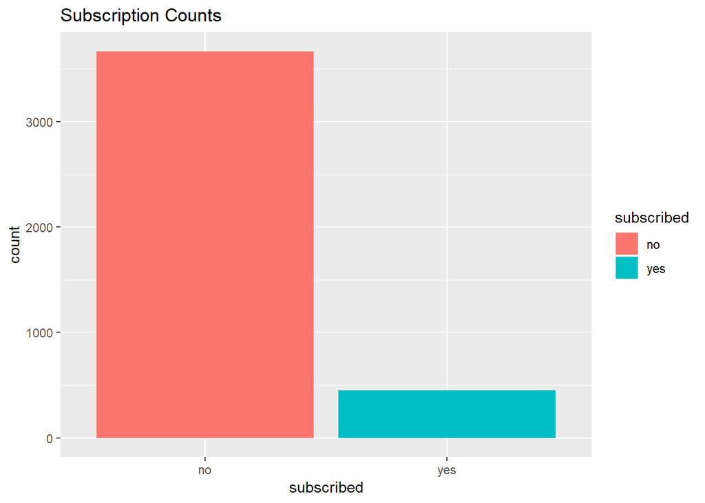

```r
ggplot(bankfull, aes(x = subscribed, fill = subscribed)) + geom_bar() +
  labs(title = "Subscription Counts")
```

The proportion of `no` to `yes` in a table:

```r
prop.table(table(bankfull$subscribed))
```

```
##
##        no       yes
## 0.8905074 0.1094926
```

When looking for clients that have subscribed to a previous campaign there are too many `nonexistent` values.

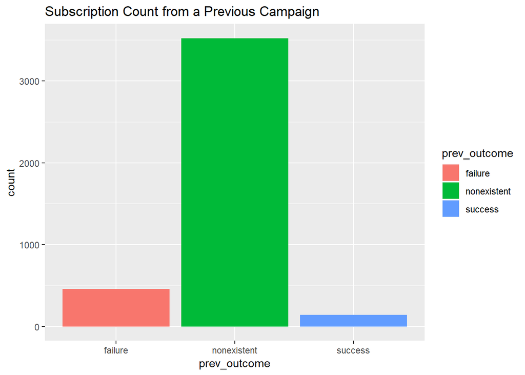

```r
ggplot(bankfull, aes(prev_outcome, fill=prev_outcome)) + geom_bar() +
  labs(title="Subscription Count from a Previous Campaign")
```

When comparing clients that subscribed to the previous campaign and the current campaign, the `nonexistent` values become distracting.

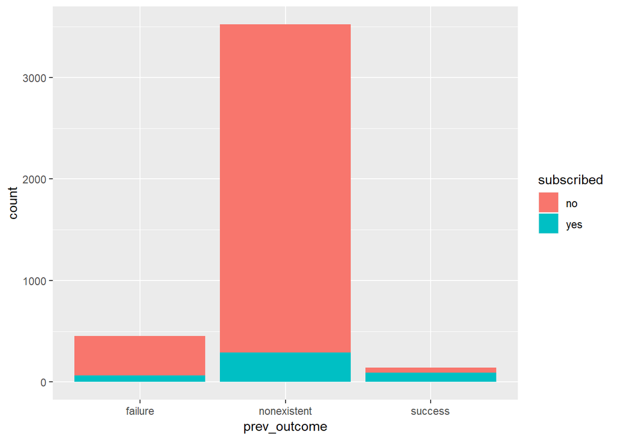

```r
ggplot(bankfull, aes(x=prev_outcome, fill=subscribed)) + geom_bar()
```

```r
ctable(bankfull$prev_outcome, bankfull$subscribed)
```

```
## Cross-Tabulation / Row Proportions
## Variables: prev_outcome * subscribed
## Data Frame: bankfull
##
## -------------- ------------ --------------- -------------- ----------------
##                  subscribed              no            yes            Total
##   prev_outcome
##        failure                 387 (85.24%)    67 (14.76%)    454 (100.00%)
##    nonexistent                3231 (91.71%)   292 ( 8.29%)   3523 (100.00%)
##        success                  50 (35.21%)    92 (64.79%)    142 (100.00%)
##          Total                3668 (89.05%)   451 (10.95%)   4119 (100.00%)
## -------------- ------------ --------------- -------------- ----------------
```

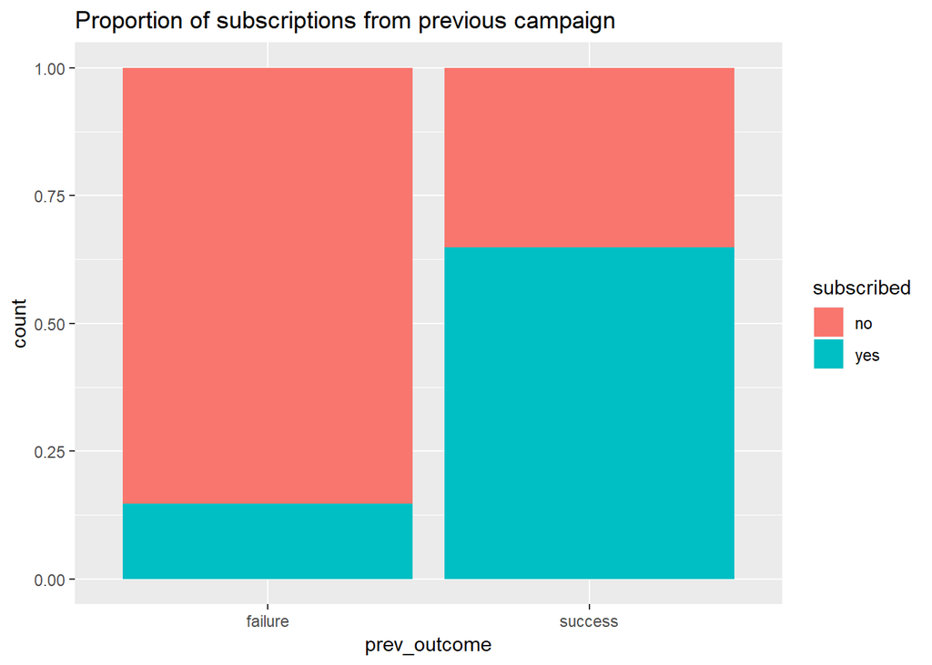

```r
bankfull_prev <- filter(bankfull, prev_outcome != "nonexistent")
ggplot(bankfull_prev, aes(x=prev_outcome, fill=subscribed)) +
  geom_bar(position="fill") +
  labs(title = "Proportion of subscriptions from previous campaign")
```

**Looking at Client Data**

Basic client data such as client age, marital status, education level or job type do not seem to show any strong trends.

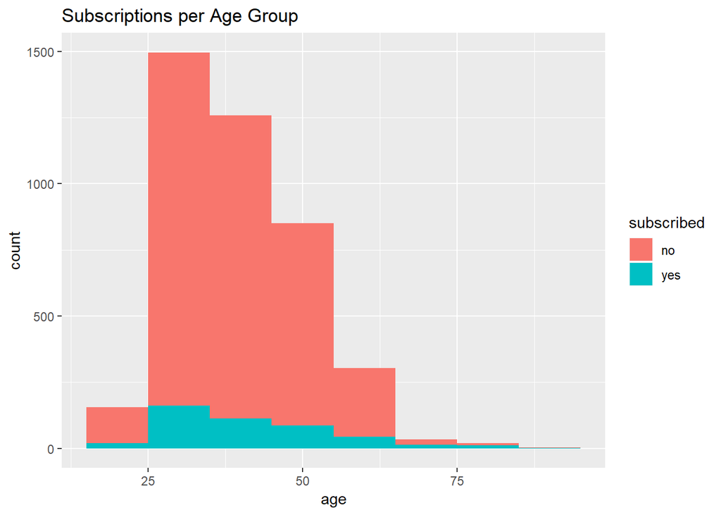

```r
ggplot(bankfull, aes(x = age, fill = subscribed)) +
  geom_histogram(binwidth=10) +
  labs(title = "Subscriptions per Age Group")
```

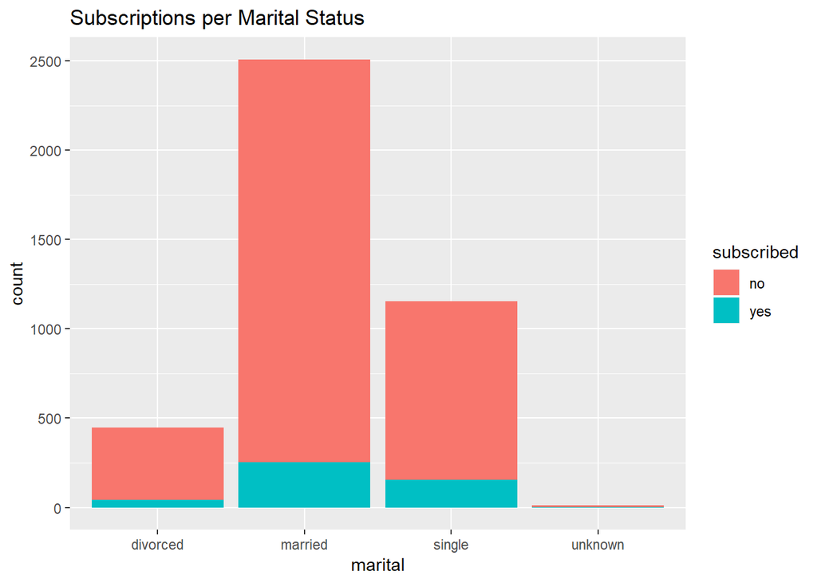

```r
ggplot(bankfull, aes(x = marital, fill = subscribed)) +
  geom_bar() +
  labs(title = "Subscriptions per Marital Status")
```

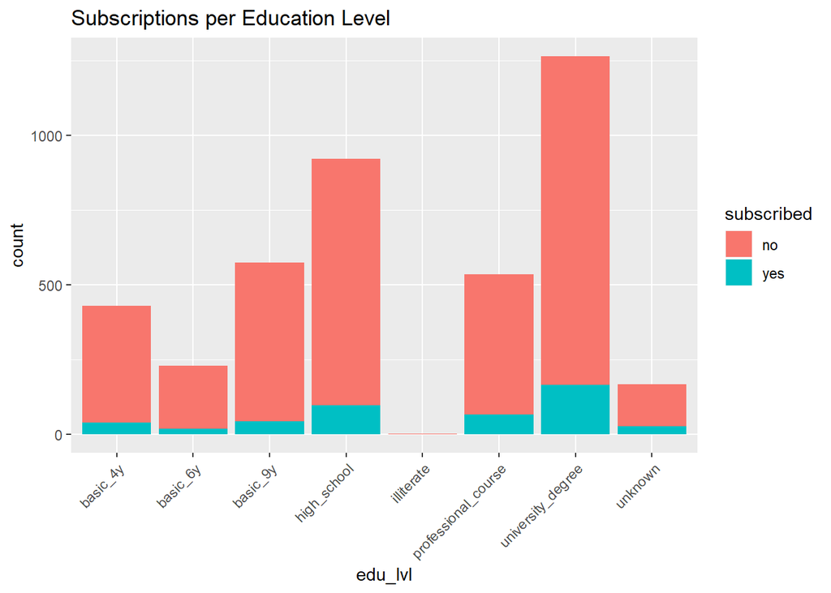

```r
ggplot(bankfull, aes(x = edu_lvl, fill = subscribed)) +
  geom_bar() +
  theme(axis.text.x = element_text(angle = 45, hjust = 1)) +
  labs(title = "Subscriptions per Education Level")
```

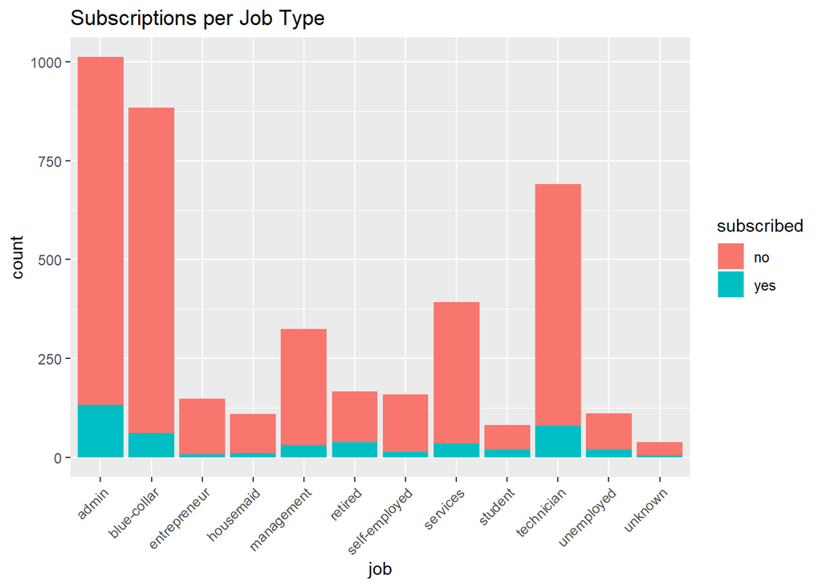

```r
ggplot(bankfull, aes(x = job, fill = subscribed)) +
  geom_bar() +
  theme(axis.text.x = element_text(angle = 45, hjust = 1)) +
  labs(title = "Subscriptions per Job Type")
```

Further review of clients’ financial records (credit in default, mortgage, or personal loan) also do not express any notable subscription trends.

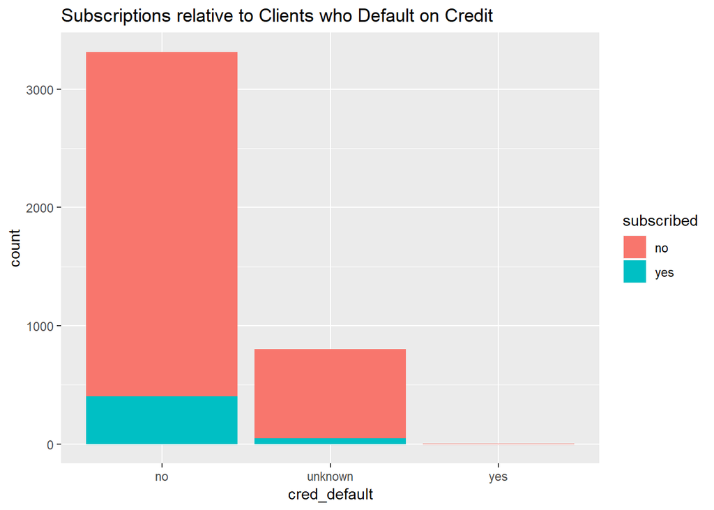

```r
#ggpairs(bankfull, columns=5:7)

ggplot(bankfull, aes(x = cred_default, fill = subscribed)) +
  geom_bar() +
  labs(title = "Subscriptions relative to Clients who Default on Credit")
```

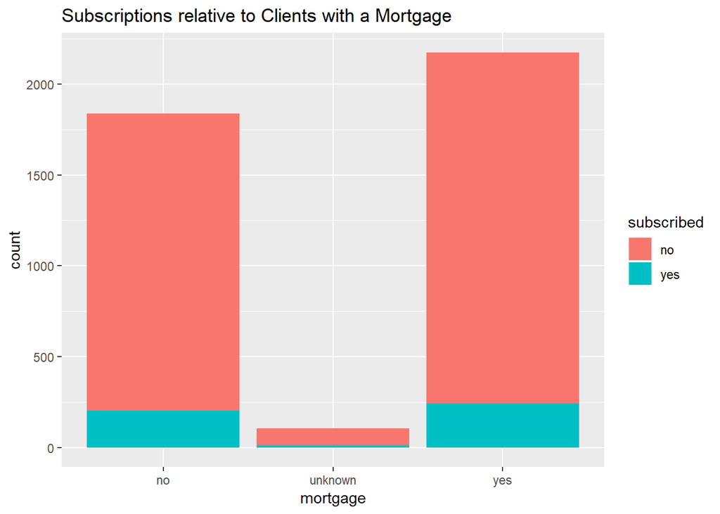

```r
ggplot(bankfull, aes(x = mortgage, fill = subscribed)) +
  geom_bar() +
  labs(title = "Subscriptions relative to Clients with a Mortgage")
```

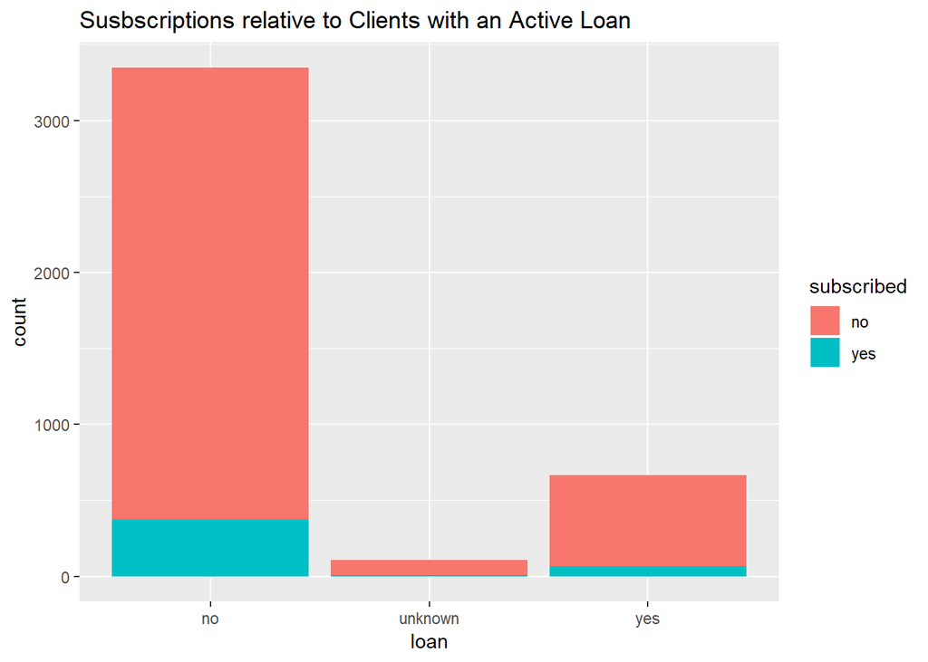

```r
ggplot(bankfull, aes(x = loan, fill = subscribed)) +
  geom_bar() +
  labs(title = "Susbscriptions relative to Clients with an Active Loan")
```

**Last Contact Data**

Last contact data will include details about the last contact with the client. Variables includ type of contact, the day and month of contact, and the duration of the last contact.

Regarding last contact data, it appears customers are more inclined to subscribe when contacted via cellular compared to telephone.

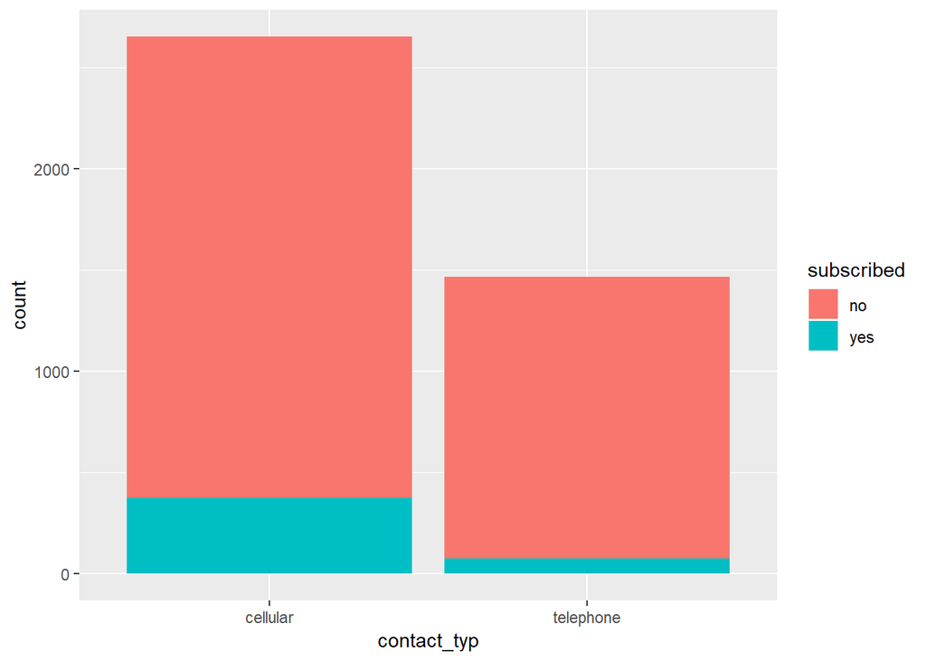

```r
ggplot(bankfull, aes(x=contact_typ, fill=subscribed)) + geom_bar()
```

```r
ctable(bankfull$contact_typ, bankfull$subscribed)
```

```
## Cross-Tabulation / Row Proportions
## Variables: contact_typ * subscribed
## Data Frame: bankfull
##
## ------------- ------------ --------------- -------------- ----------------
##                 subscribed              no            yes            Total
##   contact_typ
##      cellular                2277 (85.86%)   375 (14.14%)   2652 (100.00%)
##     telephone                1391 (94.82%)    76 ( 5.18%)   1467 (100.00%)
##         Total                3668 (89.05%)   451 (10.95%)   4119 (100.00%)
## ------------- ------------ --------------- -------------- ----------------
```

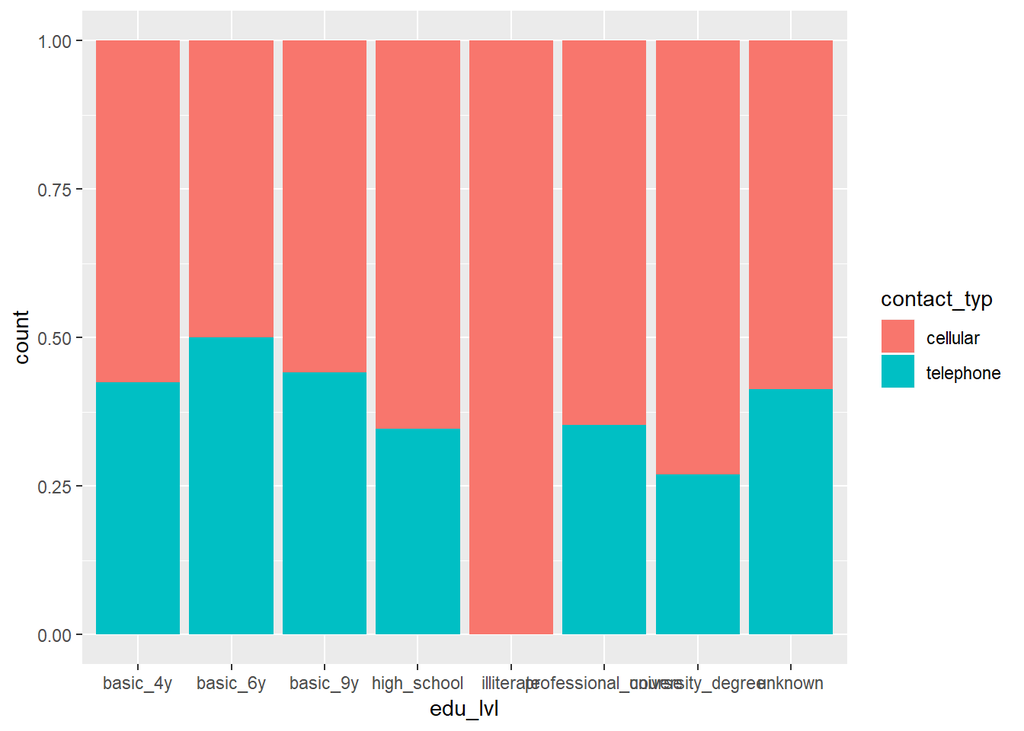

```r
ggplot(bankfull, aes(x=edu_lvl, fill=contact_typ)) + geom_bar(position="fill")
```

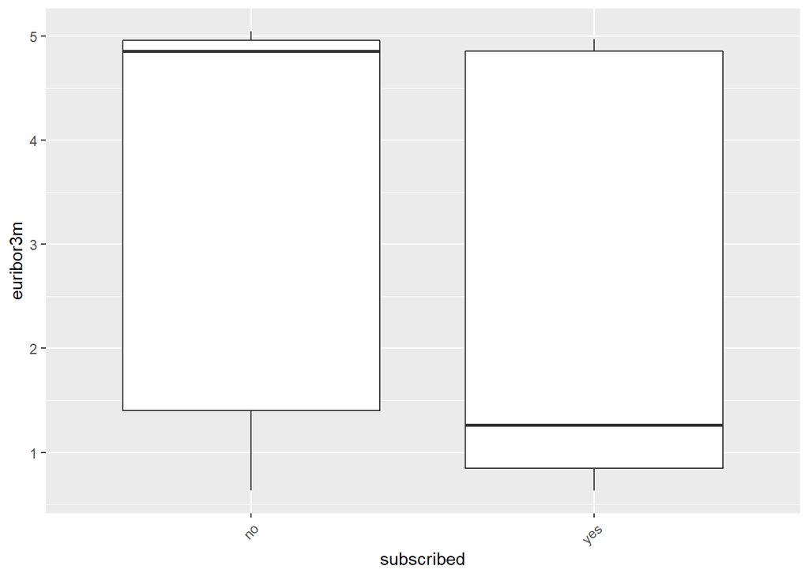

```r
ggplot(bankfull, aes(x=subscribed, y=euribor3m)) + geom_boxplot() +
  theme(axis.text.x = element_text(angle = 45, hjust = 1))
```

When looking at which month a client is most likely to subscribe, a regular bar graph by count makes it difficult. At best it looks like *May* has the most subscribers, but that doesn’t mean it’s the most likely.

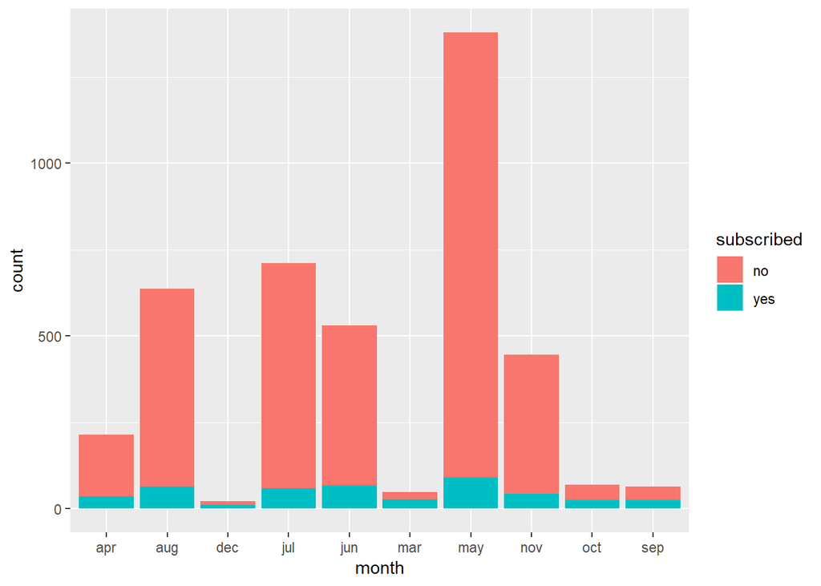

```r
ggplot(bankfull, aes(x=month, fill=subscribed)) + geom_bar()
```

If we stack each month as relative proportions we can see customers are more receptive to subscribing in *March* followed by *December* before *September*.

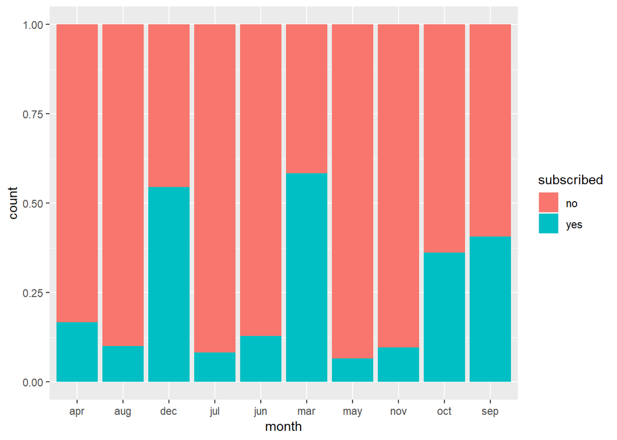

```r
ggplot(bankfull, aes(x=month, fill=subscribed)) + geom_bar(position="fill")
```

Here is a cross-tabulation of the monthly subscriptions with explicit results:

```r
ctable(bankfull$month, bankfull$subscribed)
```

```
## Cross-Tabulation / Row Proportions
## Variables: month * subscribed
## Data Frame: bankfull
##
## ------- ------------ --------------- -------------- ----------------
##           subscribed              no            yes            Total
##   month
##     apr                 179 (83.26%)    36 (16.74%)    215 (100.00%)
##     aug                 572 (89.94%)    64 (10.06%)    636 (100.00%)
##     dec                  10 (45.45%)    12 (54.55%)     22 (100.00%)
##     jul                 652 (91.70%)    59 ( 8.30%)    711 (100.00%)
##     jun                 462 (87.17%)    68 (12.83%)    530 (100.00%)
##     mar                  20 (41.67%)    28 (58.33%)     48 (100.00%)
##     may                1288 (93.47%)    90 ( 6.53%)   1378 (100.00%)
##     nov                 403 (90.36%)    43 ( 9.64%)    446 (100.00%)
##     oct                  44 (63.77%)    25 (36.23%)     69 (100.00%)
##     sep                  38 (59.38%)    26 (40.62%)     64 (100.00%)
##   Total                3668 (89.05%)   451 (10.95%)   4119 (100.00%)
## ------- ------------ --------------- -------------- ----------------
```

The most subscriptions do occur in *May* and other summer months, *June, July, and August* as confirmed by the frequency chart. Winter months *January* and *February* are absent from the dataset.

```r
monthsCampaign <- bankfull %>% filter(subscribed == "yes") %>% pull(month)
freq(monthsCampaign)
```

```
## Frequencies
## monthsCampaign
## Type: Factor (unordered)
##
##               Freq   % Valid   % Valid Cum.   % Total   % Total Cum.
## ----------- ------ --------- -------------- --------- --------------
##         apr     36      7.98           7.98      7.98           7.98
##         aug     64     14.19          22.17     14.19          22.17
##         dec     12      2.66          24.83      2.66          24.83
##         jul     59     13.08          37.92     13.08          37.92
##         jun     68     15.08          52.99     15.08          52.99
##         mar     28      6.21          59.20      6.21          59.20
##         may     90     19.96          79.16     19.96          79.16
##         nov     43      9.53          88.69      9.53          88.69
##         oct     25      5.54          94.24      5.54          94.24
##         sep     26      5.76         100.00      5.76         100.00
##        <NA>      0                               0.00         100.00
##       Total    451    100.00         100.00    100.00         100.00
```

The best day of the week for subscriptions appear to be *Monday* and *Thursday*.

```r
ctable(bankfull$day_of_week, bankfull$subscribed)
```

```
## Cross-Tabulation / Row Proportions
## Variables: day_of_week * subscribed
## Data Frame: bankfull
##
## ------------- ------------ --------------- -------------- ----------------
##                 subscribed              no            yes            Total
##   day_of_week
##           fri                 685 (89.19%)    83 (10.81%)    768 (100.00%)
##           mon                 757 (88.54%)    98 (11.46%)    855 (100.00%)
##           thu                 764 (88.84%)    96 (11.16%)    860 (100.00%)
##           tue                 750 (89.18%)    91 (10.82%)    841 (100.00%)
##           wed                 712 (89.56%)    83 (10.44%)    795 (100.00%)
##         Total                3668 (89.05%)   451 (10.95%)   4119 (100.00%)
## ------------- ------------ --------------- -------------- ----------------
```

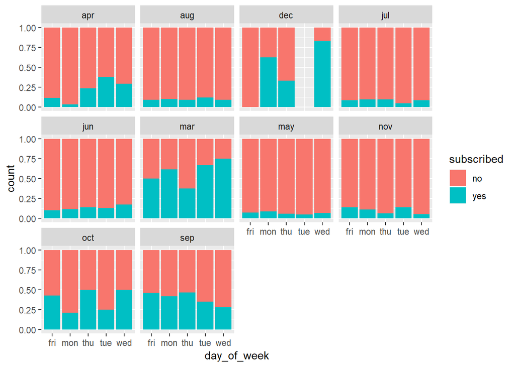

```r
ggplot(bankfull, aes(x=day_of_week, fill=subscribed)) +
  geom_bar(position="fill") +
  facet_wrap(vars(month))
```

The variable `duration` refers to the length of time in seconds spent with the customer at the last point of contact. Important note: this attribute highly affects the output target (e.g., if duration=0 then subscribed=“no”). Yet, the duration is not known before a call is performed. Also, after the end of the call *subscribed* is obviously known. Thus, this input should only be included for benchmark purposes and should be discarded if the intention is to have a realistic predictive model.

```r
descr(bankfull$duration_sec)
```

```
## Descriptive Statistics
## bankfull$duration_sec
## N: 4119
##
##                     duration_sec
## ----------------- --------------
##              Mean         256.79
##           Std.Dev         254.70
##               Min           0.00
##                Q1         103.00
##            Median         181.00
##                Q3         317.00
##               Max        3643.00
##               MAD         136.40
##               IQR         214.00
##                CV           0.99
##          Skewness           3.29
##       SE.Skewness           0.04
##          Kurtosis          20.72
##           N.Valid        4119.00
##         Pct.Valid         100.00
```

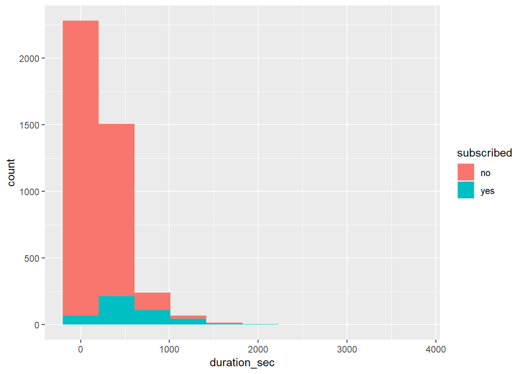

```r
ggplot(bankfull, aes(x=duration_sec, fill=subscribed)) + geom_histogram(bins=10)
```

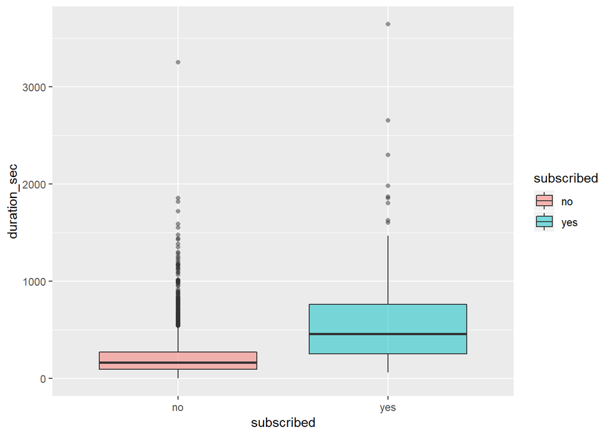

```r
ggplot(bankfull, aes(x=subscribed, y=duration_sec, fill=subscribed)) +
  geom_boxplot(outlier.shape=16, alpha=.5)
```

There’s a slight overlap in the Interquaritle Range of subscribers with the non-subscribers. That is, there’s a cut-off from the Q3 for non-subscribers and Q1 of subscribers.

```r
subscribedYES <- filter(bankfull, subscribed=="yes") %>% select(duration_sec)
descr(subscribedYES)
```

```
## Descriptive Statistics
## subscribedYES$duration_sec
## N: 451
##
##                     duration_sec
## ----------------- --------------
##              Mean         560.79
##           Std.Dev         411.54
##               Min          63.00
##                Q1         255.00
##            Median         458.00
##                Q3         762.00
##               Max        3643.00
##               MAD         339.52
##               IQR         505.50
##                CV           0.73
##          Skewness           2.04
##       SE.Skewness           0.11
##          Kurtosis           8.41
##           N.Valid         451.00
##         Pct.Valid         100.00
```

```r
subscribedNO <- filter(bankfull, subscribed=="no") %>% select(duration_sec)
descr(subscribedNO)
```

```
## Descriptive Statistics
## subscribedNO$duration_sec
## N: 3668
##
##                     duration_sec
## ----------------- --------------
##              Mean         219.41
##           Std.Dev         198.26
##               Min           0.00
##                Q1          96.00
##            Median         165.00
##                Q3         274.00
##               Max        3253.00
##               MAD         120.09
##               IQR         178.00
##                CV           0.90
##          Skewness           3.29
##       SE.Skewness           0.04
##          Kurtosis          23.86
##           N.Valid        3668.00
##         Pct.Valid         100.00
```

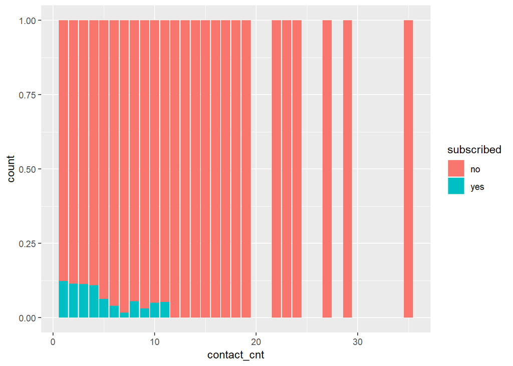

```r
ggplot(bankfull, aes(x=contact_cnt, fill=subscribed)) + geom_bar(position="fill")
```

```r
maximum_contact_cnt <- max(bankfull %>% filter(subscribed=="yes") %>%
  select(contact_cnt))
maximum_contact_cnt
```

```
## [1] 11
```

As such, the bar graph indicates clients will not subscribe if contacted by more than the maximum count value, 11.

The following density plot is for the number of days that passed from the previous campaign to the last day of contact.

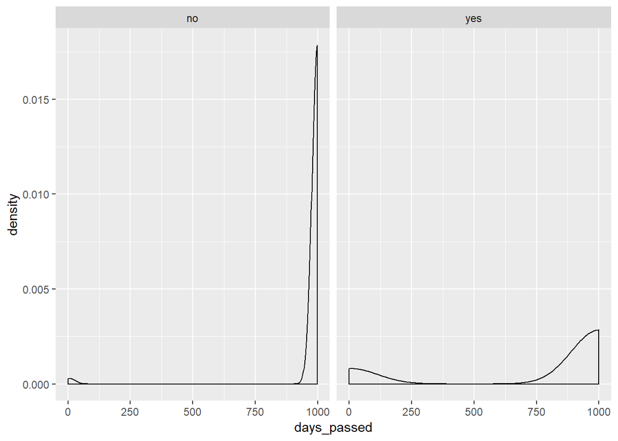

```r
ggplot(bankfull, aes(x=days_passed)) + geom_density() + facet_wrap(~subscribed)
```

```r
ctable(bankfull$days_passed, bankfull$subscribed)
```

```
## Cross-Tabulation / Row Proportions
## Variables: days_passed * subscribed
## Data Frame: bankfull
##
## ------------- ------------ ---------------- --------------- ----------------
##                 subscribed               no             yes            Total
##   days_passed
##             0                   0 (  0.00%)     2 (100.00%)      2 (100.00%)
##             1                   3 (100.00%)     0 (  0.00%)      3 (100.00%)
##             2                   3 ( 75.00%)     1 ( 25.00%)      4 (100.00%)
##             3                  13 ( 25.00%)    39 ( 75.00%)     52 (100.00%)
##             4                   9 ( 64.29%)     5 ( 35.71%)     14 (100.00%)
##             5                   0 (  0.00%)     4 (100.00%)      4 (100.00%)
##             6                  15 ( 35.71%)    27 ( 64.29%)     42 (100.00%)
##             7                   2 ( 20.00%)     8 ( 80.00%)     10 (100.00%)
##             9                   2 ( 66.67%)     1 ( 33.33%)      3 (100.00%)
##            10                   2 ( 25.00%)     6 ( 75.00%)      8 (100.00%)
##            11                   1 (100.00%)     0 (  0.00%)      1 (100.00%)
##            12                   2 ( 40.00%)     3 ( 60.00%)      5 (100.00%)
##            13                   2 (100.00%)     0 (  0.00%)      2 (100.00%)
##            14                   1 (100.00%)     0 (  0.00%)      1 (100.00%)
##            15                   1 ( 50.00%)     1 ( 50.00%)      2 (100.00%)
##            16                   2 (100.00%)     0 (  0.00%)      2 (100.00%)
##            17                   1 (100.00%)     0 (  0.00%)      1 (100.00%)
##            18                   1 ( 50.00%)     1 ( 50.00%)      2 (100.00%)
##            19                   0 (  0.00%)     1 (100.00%)      1 (100.00%)
##            21                   0 (  0.00%)     1 (100.00%)      1 (100.00%)
##           999                3608 ( 91.13%)   351 (  8.87%)   3959 (100.00%)
##         Total                3668 ( 89.05%)   451 ( 10.95%)   4119 (100.00%)
## ------------- ------------ ---------------- --------------- ----------------
```

Since we know a value of 999 means a client was not previously contacted, filtering out `days_passed` = 999 should give better insight over days passed for clients that were contacted.

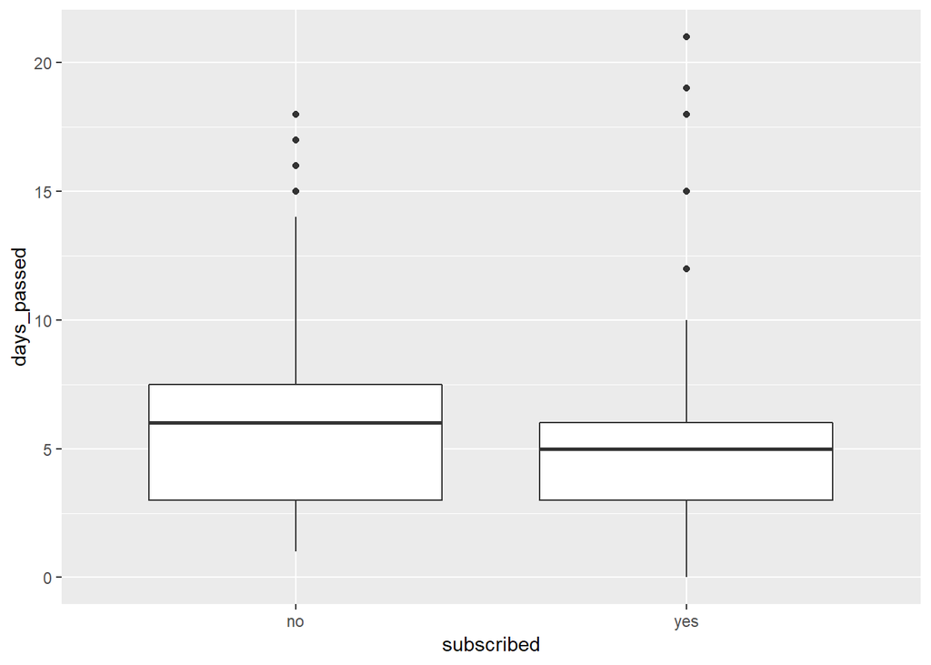

```r
daysPassedMOD <- filter(bankfull, days_passed!=999)
ggplot(daysPassedMOD, aes(x=subscribed, y=days_passed)) + geom_boxplot()
```

**Socioeconomic Data**

While generating a matrix of plots between the socioeconomic data, there looks to be a high correlation in the following 2 pairs:

- euribor3m vs employment variation rate
- euribor3m vs number employed at bank

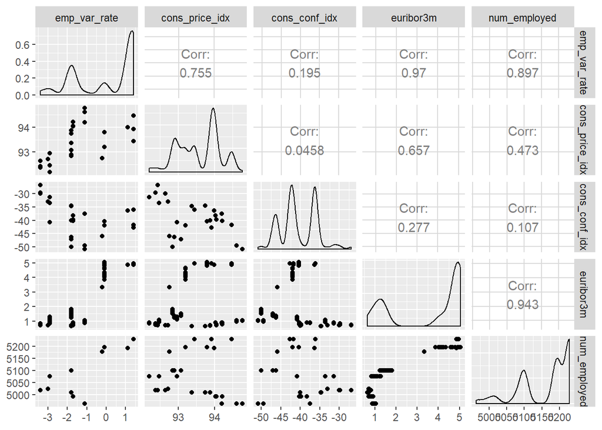

```r
# From emp_var_rate to num_employed

ggpairs(bankfull, columns=16:20, progress=FALSE)
```

**What if I filter out the subscriptions?**

Deep correlation between Employee Variation Rate and Euribor at 3 months but doesn’t seem like it affects client subscriptions.

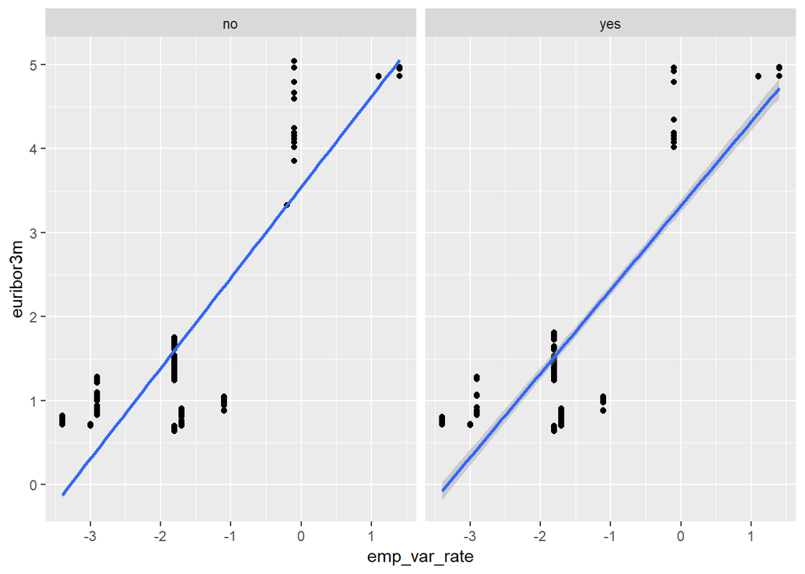

```r
ggplot(bankfull, aes(emp_var_rate, euribor3m)) + geom_point() + facet_wrap(~subscribed) + geom_smooth(method=lm)
```

Running a scatterplot for the Employment Variation Rate versus the 3 month Euribor reiterates the correlation.

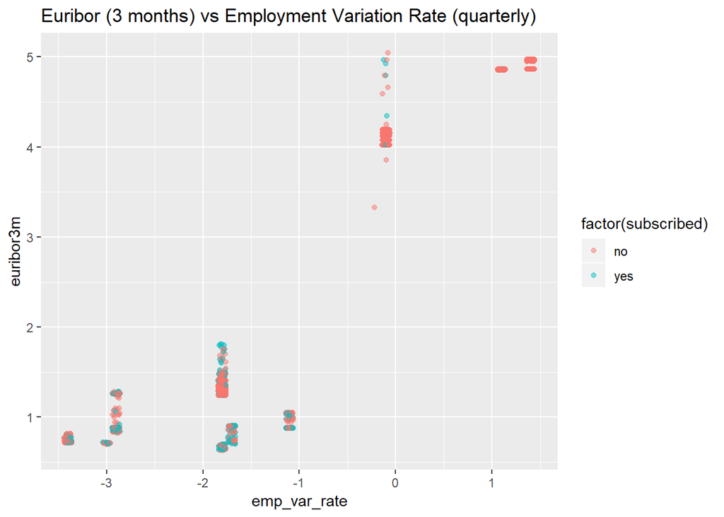

```r
ggplot(bankfull, aes(x=emp_var_rate, y=euribor3m)) +
  geom_point(aes(color = factor(subscribed)), alpha = 0.50, position="jitter") +
  labs(title = "Euribor (3 months) vs Employment Variation Rate (quarterly)")
```

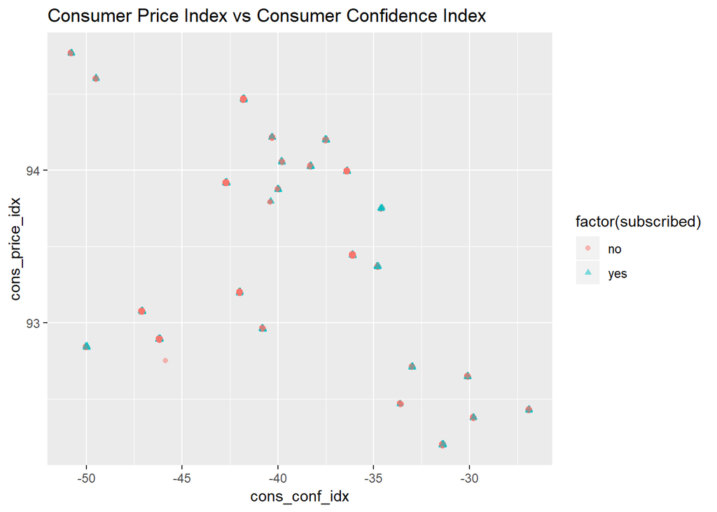

```r
ggplot(bankfull, aes(x=cons_conf_idx, y=cons_price_idx)) +
  geom_point(aes(color=factor(subscribed), shape=factor(subscribed)), alpha=0.50, position="jitter") +
  labs(title = "Consumer Price Index vs Consumer Confidence Index")
```

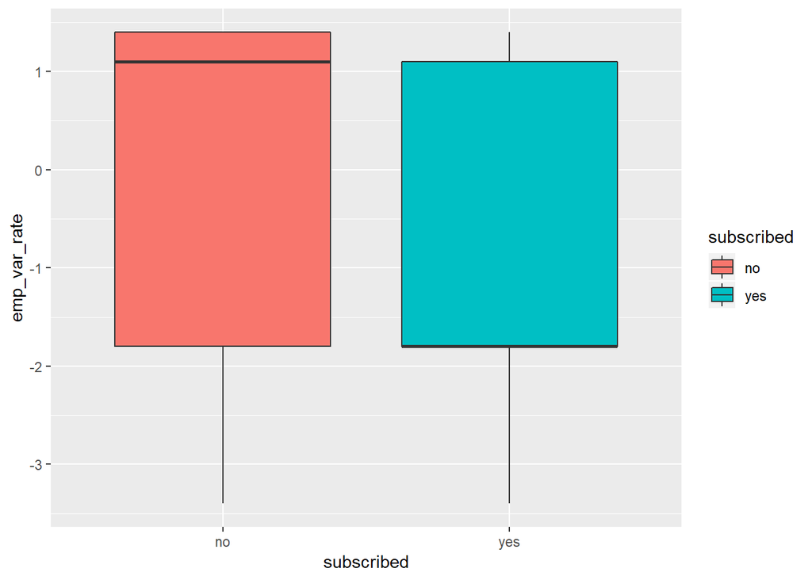

```r
ggplot(bankfull, aes(x=subscribed, y=emp_var_rate, fill=subscribed)) + geom_boxplot()
```

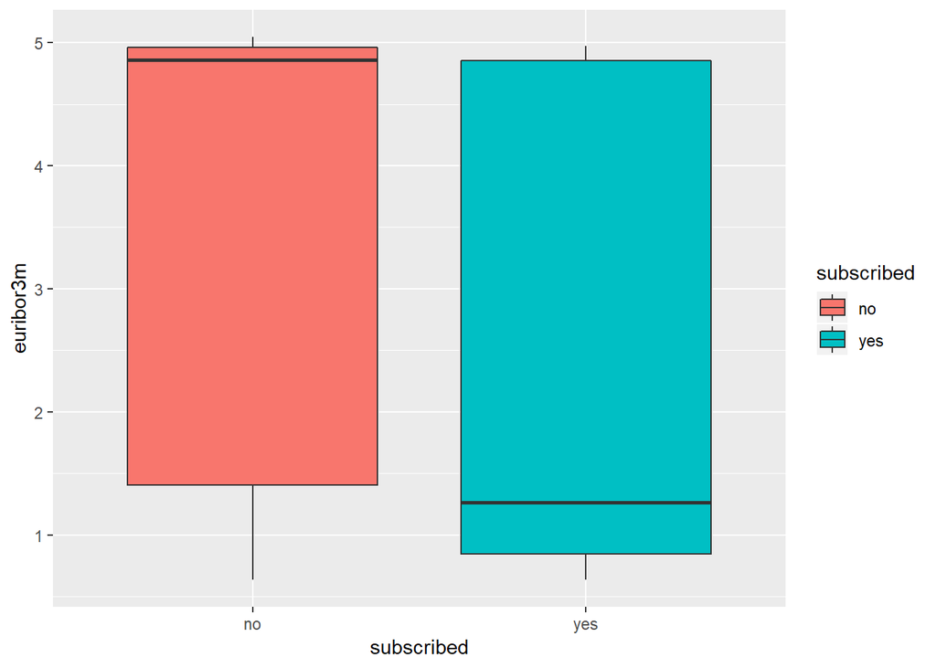

```r
ggplot(bankfull, aes(x=subscribed, y=euribor3m, fill=subscribed)) + geom_boxplot()
```

For this exploratory data analysis phase, here are a few conclusions:

1. Reach out to subscribers from previous campaign as more than 50% of subscribers will re-subscribe.
2. Contact clients via their mobile phone as the success rate is more than twice than clients contacted via a regular telephone.
3. It is advised to close a subscription by the 11th contact because there is a strong chance of rejection.
4. The length of the call should be more than 274 seconds or 4 min, 34 sec.

*Write the revised dataset into a cleaned-up file.*

```r
write_csv(bankfull, path="bankfull_clean.csv", col_names=TRUE)
```